# Multiple imputation with the mice package

## Preface

### R packages

In this practical, a number of R packages are used. If any of them are not installed you can still follow the practical but will not be able to run all of the code. The packages used (with versions that were used to generate the solutions) are:

- `mice` (version: 3.3.0)
- `JointAI` (version: 0.4.0)

### Help files

You can find help files for any function by adding a `?` before the name of the function.

Alternatively, you can look up the help pages online at https://www.rdocumentation.org/ or find the whole manual for a package at https://cran.r-project.org/web/packages/available_packages_by_name.html

## Dataset

For this practical, we will again use the **NHANES** dataset that we have seen in the previous practical.

To load this dataset, you can use the command `file.choose()` which opens the explorer and allows you to navigate to the location of the file `NHANES_for_practicals.RData` on your computer. If you know the path to the file, you can also use `load("<path>/NHANES_for_practicals.RData")`.

If you have not followed the first practical or if you re-loaded the NHANES data you need to re-code the variable `educ` again:

```r
NHANES$educ <- as.ordered(NHANES$educ)
```

## Preparing for imputation

### Set-up run

Imputation needs to be tailored to the dataset at hand and, hence, using the function `mice()` well requires several arguments to be specified. To make the specification easier it is useful to do a dry-run which will create the default versions of everything that needs to be specified.

These default settings can then be modified to what is necessary for our data.

#### Task

Do the set-up run of `mice()` with the NHANES data without any iterations (`maxit = 0`).

#### Solution

```r
# Note: This command will not produce any output.
library(mice)
imp0 <- mice(NHANES, maxit = 0)
```

### Imputation method

There are many imputation methods available in **mice**. You can find the list in the help page of the [`mice()` function](https://www.rdocumentation.org/packages/mice/versions/3.3.0/topics/mice). We will focus here on the following ones:

| name | variable type | description |
| --- | --- | --- |
| pmm | any | Predictive mean matching |
| norm | numeric | Bayesian linear regression |
| logreg | binary | Logistic regression |
| polr | ordered | Proportional odds model |
| polyreg | unordered | Polytomous logistic regression |

The default imputation methods that `mice()` selects can be specified in the argument `defaultMethod`.

If unspecified, `mice` will use

- `pmm` for numerical columns,
- `logreg` for factor columns with two categories,
- `polyreg` for columns with unordered and
- `polr` for columns with ordered factors with more than two categories.

#### Task 1

When a normal imputation model seems to be appropriate for most of the continuous covariates, you may want to specify `norm` as the default method in the setup run. Let’s do that:

The order of the types of variable is: continuous, binary, factor, ordered factor.

#### Solution 1

```r
imp0 <- mice(NHANES, maxit = 0,
             defaultMethod = c("norm", 'logreg', 'polyreg', 'polr'))
```

#### Task 2

In the histograms we made for the continuous variables during the previous practical, we could see that the variable `creat` had a skewed distribution, hence, using a normal imputation model may not work well.

- Extract the default settings of `meth` from `imp0`.
- Change the imputation method for `creat` so that this variable will be imputed using predictive mean matching.
- Check that all specified imputation methods are correct. When no imputation method is specified (`""`) the variable will not be imputed.

#### Solution 2

```r
meth <- imp0$meth
meth["creat"] <- "pmm"
meth
```

```
##     occup       BMI       HDL   hypchol    hypten       SBP      bili      educ  HyperMed     creat
## "polyreg"    "norm"    "norm"  "logreg"  "logreg"    "norm"    "norm"    "polr"    "polr"     "pmm"
##    cohort       age       DBP     smoke       wgt       alc        WC       hgt      race      chol
##        ""        ""    "norm"    "polr"    "norm"    "polr"    "norm"    "norm"        ""    "norm"
##  uricacid        DM    gender      albu
##    "norm"        ""        ""    "norm"
```

### Predictor matrix

The predictor matrix specifies which variables are used in the linear predictors of each of the imputation models.

A value of `1` specifies that the variable given in the column name is used in the model to impute the variable given in the row name (and `0` specifies that this variable is not used in that model).

#### Task 1

Get the `predictorMatrix` from `imp0`. Notice that **mice** has already set some of the values to `0`. Do you understand why?

#### Solution 1

```r
pred <- imp0$predictorMatrix
pred
```

[output not shown]

The column corresponding to the variable `cohort` is set to `0` which means that this variable is not used in any of the imputation models. `cohort` has the same value for all observations, so it would not be useful as a covariate.

#### Task 2

Because BMI is calculated from height (`hgt`) and weight (`wgt`), and there are cases where only one of these two variables is missing, we want to impute `hgt` and `wgt` separately. `BMI` should be imputed using “passive imputation”.

To avoid multicollinearity (which may lead to problems during imputation), imputation models should not include all three variables as predictor variables. In this example, we will use `BMI` to impute the other variables.

And since `HyperMed` does not give us a lot more information than `hypten`, but has a lot more missing values, we do not want to use it as a predictor variable.

Apply the necessary changes to `pred` and `meth`.

For passive imputation, you need to specify the formula used to calculate BMI in meth using `"~I(...)"`.

#### Solution 2

```r
# BMI will not be used as predictor of height and weight
pred[c("hgt", "wgt"), "BMI"] <- 0
# height and weight will not be used as predictor in any model
pred[, c("hgt", "wgt")] <- 0
# height and weight will be used as predictors for each other
pred["hgt", "wgt"] <- 1
pred["wgt", "hgt"] <- 1

# HyperMed will not be used as predictor in any model
pred[, "HyperMed"] <- 0

# hypchol will not be used as predictor in the imputation model for chol
pred["chol", "hypchol"] <- 0

# BMI will be imputed passively
meth["BMI"] <- "~I(wgt/hgt^2)"
# HyperMed will not be imputed
meth["HyperMed"] <- ""
```

### Visit sequence

The visit sequence specifies the order in which the variables are imputed.

#### Task

To be sure that the imputed values of `BMI` match the imputed values of `hgt` and `wgt`, `BMI` needs to be imputed after `hgt` and `wgt`.

- Get the `visitSequence` from `imp0`, and
- change it if necessary.

#### Solution

```r
visSeq <- imp0$visitSequence

# the lazy version:
visSeq <- c(visSeq[-2], visSeq[2])

# the save version:
# To make sure you still do the correct thing if the order of the columns in
# NHANES would change
which_BMI <- match("BMI", visSeq)
visSeq <- c(visSeq[-which_BMI], visSeq[which_BMI])
```

## Running the imputation

### Task

With the changes that we have made to the `predictorMatrix` and `method`, we can now perform the imputation. Use `m = 5` and `maxit = 10`.

### Solution

```r
imp <- mice(NHANES, method = meth, predictorMatrix = pred, visitSequence = visSeq,
            maxit = 10, m = 5,
            seed = 2019)
```

`mice()` prints the name of the variable being imputed for each iteration and imputation. If you run `mice()` on your own computer the output will show up continuously. There, you may notice that imputation is slowest for categorical variables, especially when they have many categories.

You can hide the lengthy output by specifying `printFlag = FALSE`.

## Investigate the imputation

### Type of class

#### Task

`mice()` does not return a `data.frame`. Find out the class of the object returned by `mice()` function using the function `class()`, and take a look at the [help file](https://www.rdocumentation.org/packages/mice/versions/2.46.0/topics/mids-class) for this class:

#### Solution

```r
class(imp)
```

```
## [1] "mids"
```

## Elements of the `mids` object

We see that `imp` is an object of class `mids`.

The [help file](https://www.rdocumentation.org/packages/mice/versions/2.46.0/topics/mids-class) tells us that a `mids` object is a list with several elements:

| `call`: | The call that created the `mids` object. |
| --- | --- |
| `data`: | A copy of the incomplete data set. |
| `where`: | The missingness indicator matrix. |
| `m`: | The number of imputations. |
| `nmis`: | The number of missing observations per variable. |
| `imp`: | The imputed values: A list of `ncol(data)` components,each list component is a matrix with `nmis[j]` rows and `m` columns. |
| `method`: | The vector imputation methods. |
| `predictorMatrix`: | The predictor matrix. |
| `visitSequence`: | The sequence in which columns are visited during imputation. |
| `post`: | A vector of strings of length `ncol(data)` with commands for post-processing. |
| `seed`: | The seed value of the solution. |
| `iteration`: | The number of iterations. |
| `lastSeedValue`: | The most recent seed value. |
| `chainMean:` | The mean of imputed values per variable and iteration: a list of `m` components. Each component is a matrix with `maxit`columns and `length(visitSequence)` rows. |
| `chainVar`: | The variances of imputed values per variable and iteration(same structure as `chainMean`). |
| `loggedEvents`: | A matrix with the record of automatic removal actions (details below); (`NULL` if no action was made). |
| `pad`: | A list containing the internally used version of the `data`,`method`, `predictorMatrix`, `visitSequence`, `post` and dummy coding. |

**Details of the `loggedEvents`:**

`mice()` does some pre-processing of the data:

- variables containing missing values, that are not imputed but used as predictor are removed
  - constant variables are removed
  - collinear variables are removed

Furthermore, during each iteration

- variables that are linearly dependent are removed
  - `polr` imputation that does not converge is replaced by `polyreg`.

The matrix in `loggedEvents` has the following columns:

| `it` | iteration number |
| --- | --- |
| `im` | imputation number |
| `co` | column number in the data |
| `dep` | name of the name of the variable being imputed |
| `meth` | imputation method used |
| `out` | character vector with names of altered/removed predictors |

#### Task

It is good practice to make sure that `mice()` has not done any processing of the data that was not planned or that you are not aware of. This means checking the `loggedEvents`, but also ensuring that the correct `method`, `predictorMatrix` and `visitSequence` were used.

Do these checks for `imp`.

#### Solution

```r
imp$method
```

```
##           occup             BMI             HDL         hypchol          hypten             SBP
##       "polyreg" "~I(wgt/hgt^2)"          "norm"        "logreg"        "logreg"          "norm"
##            bili            educ        HyperMed           creat          cohort             age
##          "norm"          "polr"              ""           "pmm"              ""              ""
##             DBP           smoke             wgt             alc              WC             hgt
##          "norm"          "polr"          "norm"          "polr"          "norm"          "norm"
##            race            chol        uricacid              DM          gender            albu
##              ""          "norm"          "norm"              ""              ""          "norm"
```

```r
imp$predictorMatrix
```

```
##          occup BMI HDL hypchol hypten SBP bili educ HyperMed creat cohort age DBP smoke wgt alc WC
## occup        0   1   1       1      1   1    1    1        0     1      0   1   1     1   0   1  1
## BMI          1   0   1       1      1   1    1    1        0     1      0   1   1     1   0   1  1
## HDL          1   1   0       1      1   1    1    1        0     1      0   1   1     1   0   1  1
## hypchol      1   1   1       0      1   1    1    1        0     1      0   1   1     1   0   1  1
## hypten       1   1   1       1      0   1    1    1        0     1      0   1   1     1   0   1  1
## SBP          1   1   1       1      1   0    1    1        0     1      0   1   1     1   0   1  1
## bili         1   1   1       1      1   1    0    1        0     1      0   1   1     1   0   1  1
## educ         1   1   1       1      1   1    1    0        0     1      0   1   1     1   0   1  1
## HyperMed     1   1   1       1      1   1    1    1        0     1      0   1   1     1   0   1  1
## creat        1   1   1       1      1   1    1    1        0     0      0   1   1     1   0   1  1
## cohort       1   1   1       1      1   1    1    1        0     1      0   1   1     1   0   1  1
## age          1   1   1       1      1   1    1    1        0     1      0   0   1     1   0   1  1
## DBP          1   1   1       1      1   1    1    1        0     1      0   1   0     1   0   1  1
## smoke        1   1   1       1      1   1    1    1        0     1      0   1   1     0   0   1  1
## wgt          1   0   1       1      1   1    1    1        0     1      0   1   1     1   0   1  1
## alc          1   1   1       1      1   1    1    1        0     1      0   1   1     1   0   0  1
## WC           1   1   1       1      1   1    1    1        0     1      0   1   1     1   0   1  0
## hgt          1   0   1       1      1   1    1    1        0     1      0   1   1     1   1   1  1
## race         1   1   1       1      1   1    1    1        0     1      0   1   1     1   0   1  1
## chol         1   1   1       0      1   1    1    1        0     1      0   1   1     1   0   1  1
## uricacid     1   1   1       1      1   1    1    1        0     1      0   1   1     1   0   1  1
## DM           1   1   1       1      1   1    1    1        0     1      0   1   1     1   0   1  1
## gender       1   1   1       1      1   1    1    1        0     1      0   1   1     1   0   1  1
## albu         1   1   1       1      1   1    1    1        0     1      0   1   1     1   0   1  1
##          hgt race chol uricacid DM gender albu
## occup      0    1    1        1  1      1    1
## BMI        0    1    1        1  1      1    1
## HDL        0    1    1        1  1      1    1
## hypchol    0    1    1        1  1      1    1
## hypten     0    1    1        1  1      1    1
## SBP        0    1    1        1  1      1    1
## bili       0    1    1        1  1      1    1
## educ       0    1    1        1  1      1    1
## HyperMed   0    1    1        1  1      1    1
## creat      0    1    1        1  1      1    1
## cohort     0    1    1        1  1      1    1
## age        0    1    1        1  1      1    1
## DBP        0    1    1        1  1      1    1
## smoke      0    1    1        1  1      1    1
## wgt        1    1    1        1  1      1    1
## alc        0    1    1        1  1      1    1
## WC         0    1    1        1  1      1    1
## hgt        0    1    1        1  1      1    1
## race       0    0    1        1  1      1    1
## chol       0    1    0        1  1      1    1
## uricacid   0    1    1        0  1      1    1
## DM         0    1    1        1  0      1    1
## gender     0    1    1        1  1      0    1
## albu       0    1    1        1  1      1    0
```

```r
imp$visitSequence
```

```
##  [1] "occup"    "HDL"      "hypchol"  "hypten"   "SBP"      "bili"     "educ"     "HyperMed"
##  [9] "creat"    "cohort"   "age"      "DBP"      "smoke"    "wgt"      "alc"      "WC"
## [17] "hgt"      "race"     "chol"     "uricacid" "DM"       "gender"   "albu"     "BMI"
```

```r
imp$loggedEvents
```

[output not shown]

### Logged events

Checking the `loggedEvents` we see that for `alc`, `educ` and `smoke` the method `multinom` was used. That is a bit confusing: we specified `polr` in our imputation method and `imp$method` is indeed `polr` for the three ordinal variables.

The `mice` help page told us that in case `polr` does not converge `polyreg` will be used.

#### Task 1

Find out if there is more information in the [help](https://www.rdocumentation.org/packages/mice/versions/2.46.0/topics/mice.impute.polr) [pages](https://www.rdocumentation.org/packages/mice/versions/2.46.0/topics/mice.impute.polyreg) for those two functions.

Using `polr` and `polyreg` when specifying the `method` argument in `mice` actually calls the functions `mice.impute.polr` and `mice.impute.polyreg` when running the imputation.

#### Solution 1

The help for `mice.impute.polr()` tells us:

> The call to `polr` might fail, usually because the data are very sparse. In that case, `multinom` is tried as a fallback, and a record is written to the `loggedEvents` component of the `mids` object.

and the help for `mice.impute.polyreg()` says:

> The algorithm of `mice.impute.polyreg` uses the function `multinom()` from the **nnet** package.

So that explains it, everything seems to be in order, but unfortunately the ordinal models for `alc`, `educ` and `smoke` did not converge and multinomial models had to be used instead.

#### Task 2

Let’s see what else would have come up if we had not prepared the `predictorMatrix`, `method` and `visitSequence` before imputation. The object `impnaive` contains the result of

```r
impnaive <- mice(NHANES, m = 5, maxit = 10)
```

Take a look at the `loggedEvents` of `impnaive`.

#### Solution 2

```r
impnaive$loggedEvents
```

|  | it | im | dep | meth | out |
| --- | --- | --- | --- | --- | --- |
| 1 | 0 | 0 |  | constant | cohort |
| 2 | 1 | 1 | HyperMed | polr | hyptenyes, wgt |
| 3 | 1 | 1 | alc | polr | hgt |
| 4 | 1 | 2 | HyperMed | polr | hyptenyes, wgt |
| 5 | 1 | 3 | HyperMed | polr | hyptenyes, wgt |
| 6 | 1 | 3 | alc | polr | hgt |
| 7 | 1 | 4 | HyperMed | polr | hyptenyes, wgt |
| 8 | 1 | 4 | alc | polr | hgt |
| 9 | 1 | 5 | HyperMed | polr | hyptenyes, wgt |
| 10 | 1 | 5 | alc | polr | hgt |

[output cut: 84 more lines]

The `loggedEvents` of the “naive” imputation show that the constant variable `cohort` was excluded before the imputation (as it should be).

```r
impnaive$pad$categories
```

[output not shown]

#### Task 3

We also did not change the `visitSequence` in `impnaive`. Find out what the effects of that are.

#### Solution 3

```r
naiveDF1 <- complete(impnaive, 1)
naivecalcBMI <- with(naiveDF1, wgt/hgt^2)

impDF1 <- complete(imp, 1)
impcalcBMI <- with(impDF1, wgt/hgt^2)

cbind(naiveBMI = naiveDF1$BMI, naivecalcBMI,
      impBMI = impDF1$BMI, impcalcBMI)[which(is.na(NHANES$BMI)), ]
```

```
##      naiveBMI naivecalcBMI       impBMI   impcalcBMI
## [1,] 35.89982     35.15348 -64.12450179 -64.12450179
## [2,] 36.12996     28.31808   0.05864647   0.05864647
## [3,] 41.24675     27.81102   0.83115460   0.83115460
## [4,] 41.24675     21.59080   1.12941634   1.12941634
## [5,] 36.03140     38.40911   0.67299102   0.67299102
## [6,] 31.73578     19.46213   1.24100269   1.24100269
```

When we compare the imputed and calculated values of `BMI` from `impnaive` we can see that the imputed `hgt` and `wgt` give a different `BMI` than is imputed. This is because `BMI` is imputed before `wgt`, which means that the most recent imputed value of `wgt` is from the previous iteration.

Changing the `visitSequence` in `imp` prevented this inconsistency.

### Convergence

The mean and variance of the imputed values per iteration and variable is stored in the elements `chainMean` and `chainVar` of the `mids` object.

#### Task

Let’s plot them to see if our imputation `imp` has converged:

#### Solution

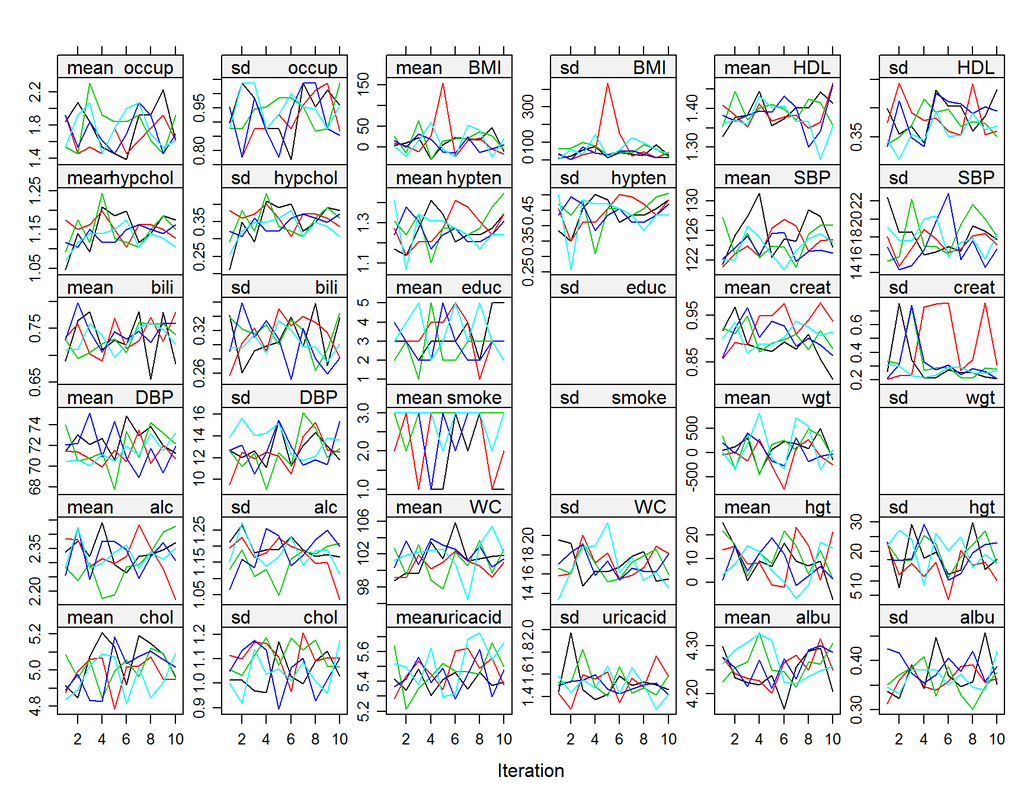

```r
# implemented plotting function (use layout to change the number of rows and columns)
plot(imp, layout = c(6, 6))
```

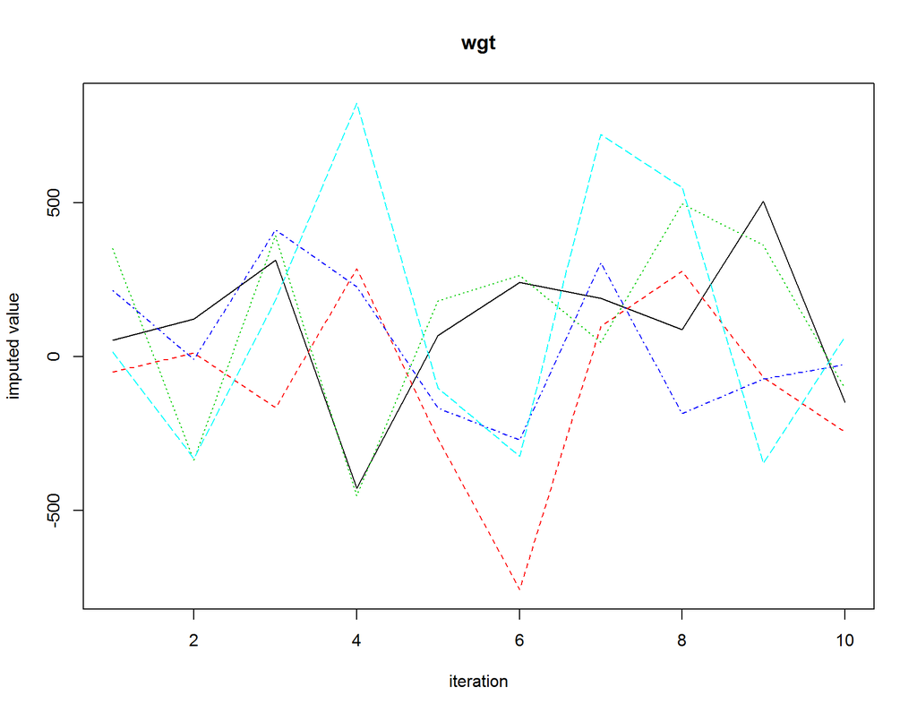

```r
# plot for a single variable
matplot(imp$chainMean["wgt", , ], type = "l", ylab = "imputed value",
        xlab = "iteration", main = "wgt")
```

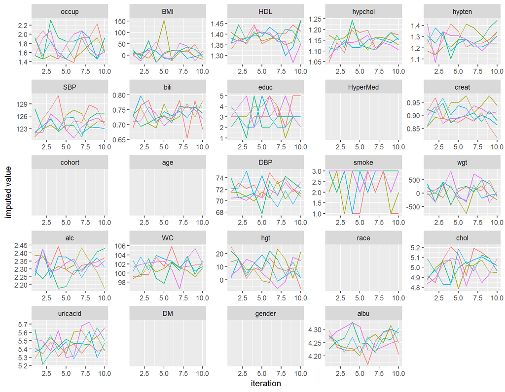

```r
# or the ggplot version
library(ggplot2)
library(reshape2)
ggplot(melt(imp$chainMean), aes(x = Var2, y = value, color = Var3)) +
  geom_line() +
  facet_wrap("Var1", scales = 'free') +
  theme(legend.position = 'none') +
  xlab("iteration") +
  ylab("imputed value")
```

The chains in `imp` seem to have converged, but in practice, more iterations should be done to confirm this.

#### Continue

In comparison, `impnaive` had some convergence problems:

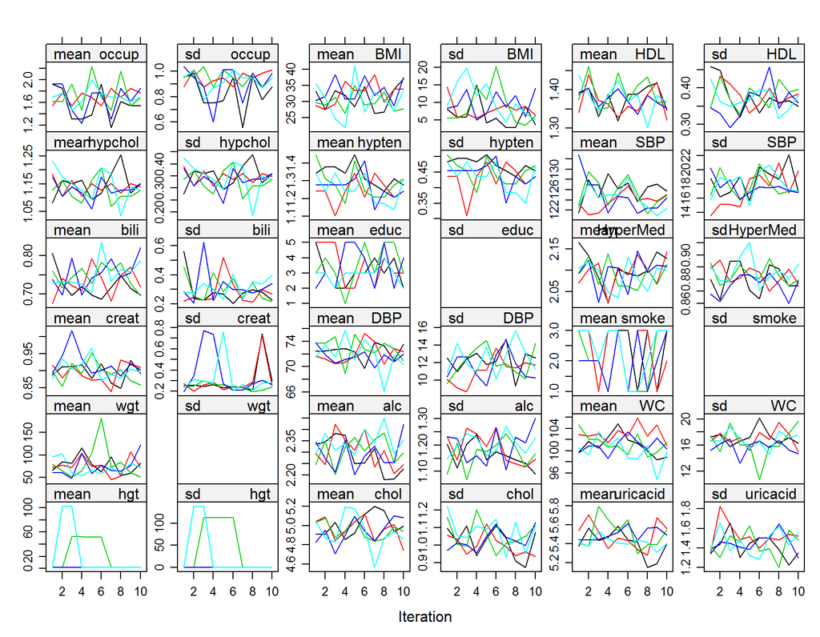

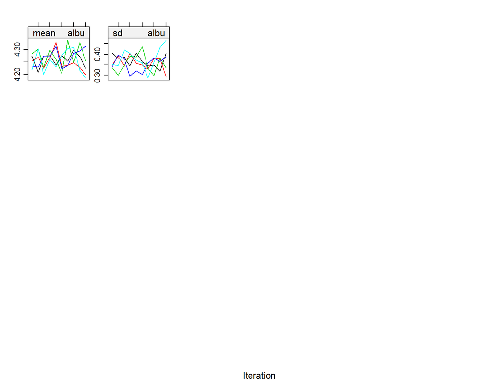

```r
plot(impnaive, layout = c(6, 6))
```

### Imputed values

Now that we know that `imp` has converged, we can compare the distribution of the imputed values against the distribution of the observed values.

#### Task

Plot the distributions of the imputed variables (continuous and categorical), and make sure the imputed values are realistic (e.g., height of 2.50m or weight of 10kg for adults). If there are differences in the distributions of observed and imputed values see if those differences can be explained by other variables.

You can use `densityplot()` and `probplot()` to get plots for all continuous and categorical variables.

You can obtain `probplot()` from https://gist.github.com/NErler/0d00375da460dd33839b98faeee2fdab.

To check all imputed values you can either get a summary of the `imp` element of the `mids` object or create a complete dataset containing all imputations using the function `complete()` and get the summary of that.

#### Solution

```r
densityplot(imp)

# create a long dataset with all imputed data sets stacked onto each other
longDF <- complete(imp, "long")
summary(longDF)

# get the summary of the "raw" imputed values
lapply(imp$imp, function(x)
  summary(unlist(x))
)

# look into the distribution of SBP and height
densityplot(imp, ~SBP|hypten)
densityplot(imp, ~hgt|gender)

# plot for all categorical variables
probplot(imp)

# look into the categorical variables where proportions of imputed and observed differ
probplot(imp, smoke ~ alc)
probplot(imp, alc ~ gender)
```

[output not shown]

Unfortunately, we have some negative imputed values for `bili`. Often, this would not result in bias in the analysis, but may be difficult to explain when providing a summary of the imputed data in a publication. In the present example we can see that the observed values have a slightly right-skewed distribution, compared to the imputed values. Re-doing the imputation with `pmm` instead of `norm` for `bili` should fix this. (However, since the imputations seem fine overall, and there is little knowledge gain in re-doing the previous steps, we will skip this repetition in this practical.)

The distributions of the imputed values for `hgt` and `SBP` differ a bit from the distributions of the observed data, but these differences can be explained by adjusting for `gender` and `hypten`.

We also imputed a larger proportion than might have been expected in the highest category of `alc`, and the distribution of values for `educ` and `smoke` looks a bit weird.

The difference in distribution of `alc` could be explained by `gender`. `smoke` and `educ` each have only one missing value, which makes it difficult to judge the distribution of imputed values. Adjusting the distributions of observed `smoke` for `alc` shows that the subject with missing smoking status was a drinker, and drinkers were more often in the `current` group of smoking.